# rumeysanazli

# i. Veri setinizin kaynagini belirtiniz. Bagimli ve aciklayici degiskenleri tanimlayiniz.

```r
library(readr)
library(summarytools)
```

```r
library(ggplot2)
library(tidyverse)
library(treemap)
library(ggridges)
library(gridExtra)
library(corrplot)
library(dplyr)
library(tidyr)
library(plot3D)
library(boot)
```

```r
library(readr)
Admission_Predict <- read_csv("C:/Users/IB-PC16/Desktop/Admission_Predict.csv",
    col_types = cols(Research = col_factor(levels = c("0",
        "1")), UniRating = col_factor(levels = c("1",
        "2", "3", "4", "5"))))
str(Admission_Predict)
```

```
## Classes 'spec_tbl_df', 'tbl_df', 'tbl' and 'data.frame': 400 obs. of  9 variables:
##  $ Serial No.   : num  1 2 3 4 5 6 7 8 9 10 ...
##  $ GREScore     : num  337 324 316 322 314 330 321 308 302 323 ...
##  $ TOEFLScore   : num  118 107 104 110 103 115 109 101 102 108 ...
##  $ UniRating    : Factor w/ 5 levels "1","2","3","4",..: 4 4 3 3 2 5 3 2 1 3 ...
##  $ SOP          : num  4.5 4 3 3.5 2 4.5 3 3 2 3.5 ...
##  $ LOR          : num  4.5 4.5 3.5 2.5 3 3 4 4 1.5 3 ...
##  $ CGPA         : num  9.65 8.87 8 8.67 8.21 9.34 8.2 7.9 8 8.6 ...
##  $ Research     : Factor w/ 2 levels "0","1": 2 2 2 2 1 2 2 1 1 1 ...
##  $ ChanceofAdmit: num  0.92 0.76 0.72 0.8 0.65 0.9 0.75 0.68 0.5 0.45 ...
##  - attr(*, "spec")=
##   .. cols(
##   ..   `Serial No.` = col_double(),
##   ..   GREScore = col_double(),
##   ..   TOEFLScore = col_double(),
##   ..   UniRating = col_factor(levels = c("1", "2", "3", "4", "5"), ordered = FALSE, include_na = FALSE),
##   ..   SOP = col_double(),
##   ..   LOR = col_double(),
##   ..   CGPA = col_double(),
##   ..   Research = col_factor(levels = c("0", "1"), ordered = FALSE, include_na = FALSE),
##   ..   ChanceofAdmit = col_double()
##   .. )
```

```r
attach(Admission_Predict)
```

# DETAYLI ISTATISTIKSEL ANALIZ

```r
library(summarytools)
descr(Admission_Predict)
```

```
## Non-numerical variable(s) ignored: UniRating, Research
```

```
## Descriptive Statistics
## Admission_Predict
## N: 400
##
##                       CGPA   ChanceofAdmit   GREScore      LOR   Serial No.      SOP   TOEFLScore
## ----------------- -------- --------------- ---------- -------- ------------ -------- ------------
##              Mean     8.60            0.72     316.81     3.45       200.50     3.40       107.41
##          Std.Dev.     0.60            0.14      11.47     0.90       115.61     1.01         6.07
##               Min     6.80            0.34     290.00     1.00         1.00     1.00        92.00
##                Q1     8.17            0.64     308.00     3.00       100.50     2.50       103.00
##            Median     8.61            0.73     317.00     3.50       200.50     3.50       107.00
##                Q3     9.07            0.83     325.00     4.00       300.50     4.00       112.00
##               Max     9.92            0.97     340.00     5.00       400.00     5.00       120.00
##               MAD     0.67            0.13      11.86     0.74       148.26     0.74         5.93
##               IQR     0.89            0.19      17.00     1.00       199.50     1.50         9.00
##                CV     0.07            0.20       0.04     0.26         0.58     0.30         0.06
##          Skewness    -0.07           -0.35      -0.06    -0.11         0.00    -0.27         0.06
##       SE.Skewness     0.12            0.12       0.12     0.12         0.12     0.12         0.12
##          Kurtosis    -0.48           -0.41      -0.72    -0.68        -1.21    -0.69        -0.60
##           N.Valid   400.00          400.00     400.00   400.00       400.00   400.00       400.00
##           % Valid   100.00          100.00     100.00   100.00       100.00   100.00       100.00
```

```r
freq(Admission_Predict)
```

```
## Variable(s) ignored: Serial No., GREScore, TOEFLScore, SOP, LOR, CGPA
```

```
## Frequencies
## Admission_Predict$UniRating
## Type: Factor
##
##               Freq   % Valid   % Valid Cum.   % Total   % Total Cum.
## ----------- ------ --------- -------------- --------- --------------
##           1     26      6.50           6.50      6.50           6.50
##           2    107     26.75          33.25     26.75          33.25
##           3    133     33.25          66.50     33.25          66.50
##           4     74     18.50          85.00     18.50          85.00
##           5     60     15.00         100.00     15.00         100.00
##        <NA>      0                               0.00         100.00
##       Total    400    100.00         100.00    100.00         100.00
##
## Admission_Predict$Research
## Type: Factor
##
##               Freq   % Valid   % Valid Cum.   % Total   % Total Cum.
## ----------- ------ --------- -------------- --------- --------------
##           0    181     45.25          45.25     45.25          45.25
##           1    219     54.75         100.00     54.75         100.00
##        <NA>      0                               0.00         100.00
##       Total    400    100.00         100.00    100.00         100.00
```

# BAZI DETAYLAR

```r
which.max(TOEFLScore)  #26. kisi=120 puan
```

```
## [1] 26
```

```r
range(TOEFLScore)      #min=92,max=120
```

```
## [1]  92 120
```

```r
range(ChanceofAdmit)   #min=0.34,max=0.97
```

```
## [1] 0.34 0.97
```

```r
which.max(ChanceofAdmit) #25. kisi
```

```
## [1] 25
```

```r
range(CGPA)
```

```
## [1] 6.80 9.92
```

### iii. Veri setinizdeki degiskenler icin uygun gorsellestirmeleri yapiniz.

# BOXPLOT

```r
library(ggplot2)
head(GREScore)
```

```
## [1] 337 324 316 322 314 330
```

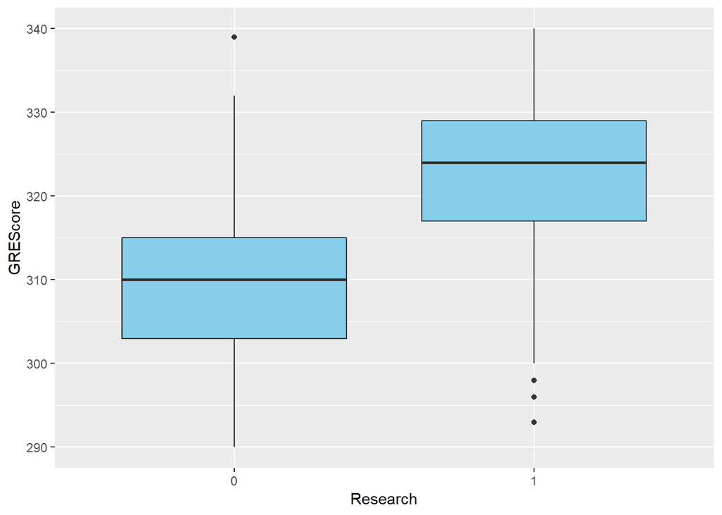

```r
ggplot(Admission_Predict, aes(x=Research, y=GREScore)) +
  geom_boxplot(fill="skyblue", aes(group = cut_width(Research, 0.5)))
```

Arastirma yapanlarin cogunun mezuniyet notu daha yuksek diyebiliriz. ancak bazi aykiri degerler vardir.

# BUBBLE CHART

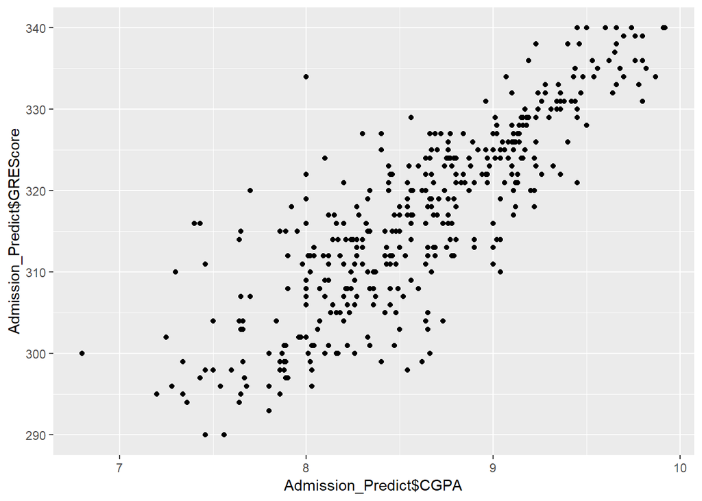

```r
library(tidyverse)
data = Admission_Predict
ggplot(data, aes(x=Admission_Predict$CGPA, y=Admission_Predict$GREScore)) +
  geom_point()
```

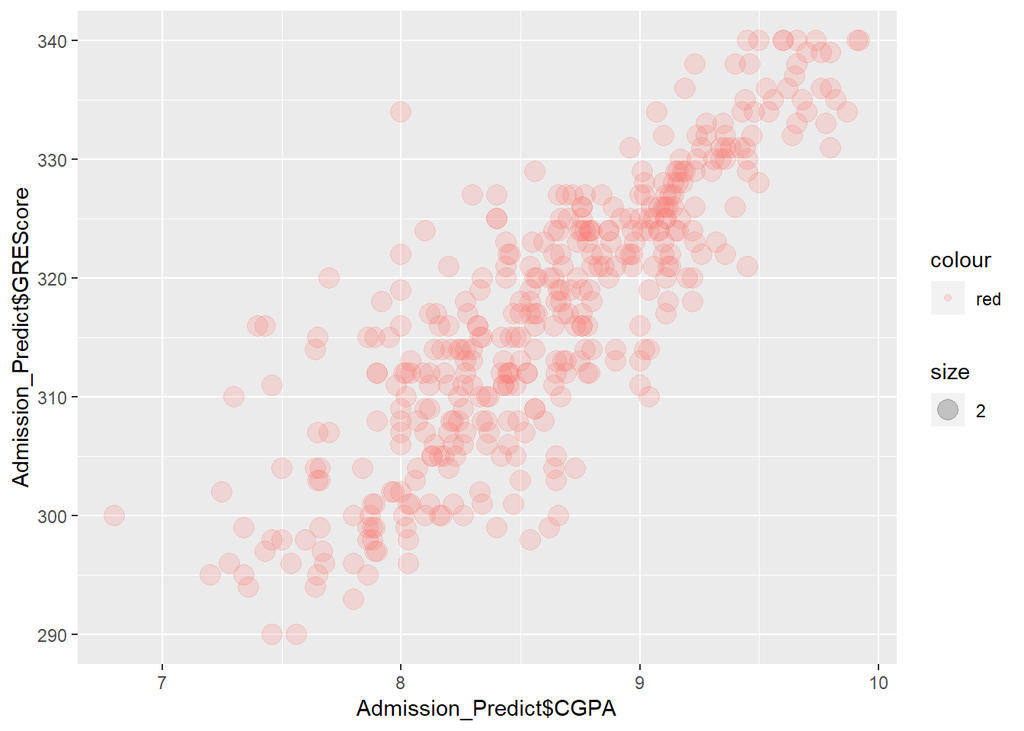

```r
ggplot(data, aes(x=Admission_Predict$CGPA, y=Admission_Predict$GREScore,size = 2, colour = "red")) +
  geom_point(alpha=0.2)
```

Mezuniyet notlari ve donem sonu agirlikli puanlar arasinda dogrusal bir iliski vardir diyebiliriz. Yani donem sonu notlari arttikca mezuniyet notlari da artmaktadir.

# TREEMAP CHART

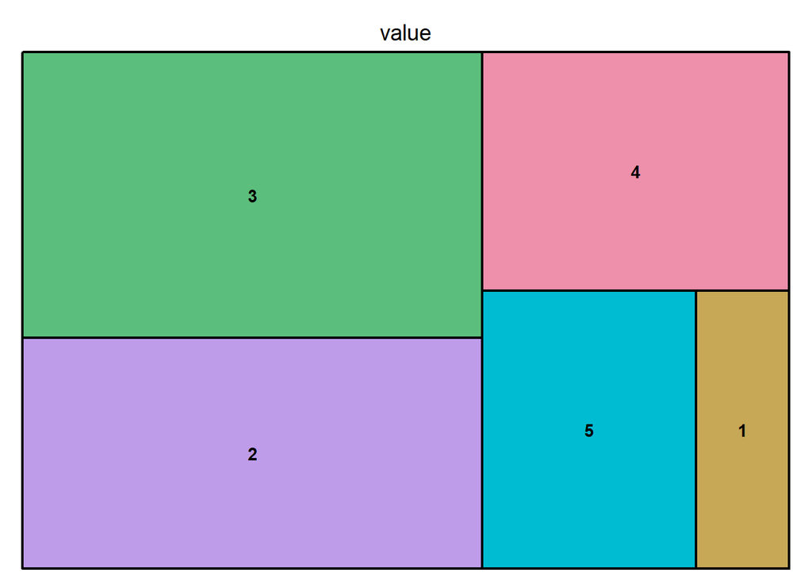

```r
library(treemap)
# Create data
group=c("1","2","3","4","5")
value=c(26,107,133,74,60)
data=data.frame(group,value)
# treemap
treemap(data,
        index="group",
        vSize="value",
        type="index")
```

Burada üniversite oylarinin bir alana dagilmis halini goruyoruz. Bu tablodan veriyi yorumlamak daha basit ornegin; notu 3 olanlar 1 olanlardan daha fazladir yada notu 5 olanlar 2 olanlardan daha azdir gibi yorumlar yapabiliriz.

# BASIC RIDGELINE PLOT

```r
library(ggridges)
library(ggplot2)

head(Admission_Predict)
```

```
## # A tibble: 6 x 9
##   `Serial No.` GREScore TOEFLScore UniRating   SOP   LOR  CGPA Research
##          <dbl>    <dbl>      <dbl> <fct>     <dbl> <dbl> <dbl> <fct>
## 1            1      337        118 4           4.5   4.5  9.65 1
## 2            2      324        107 4           4     4.5  8.87 1
## 3            3      316        104 3           3     3.5  8    1
## 4            4      322        110 3           3.5   2.5  8.67 1
## 5            5      314        103 2           2     3    8.21 0
## 6            6      330        115 5           4.5   3    9.34 1
## # ... with 1 more variable: ChanceofAdmit <dbl>
```

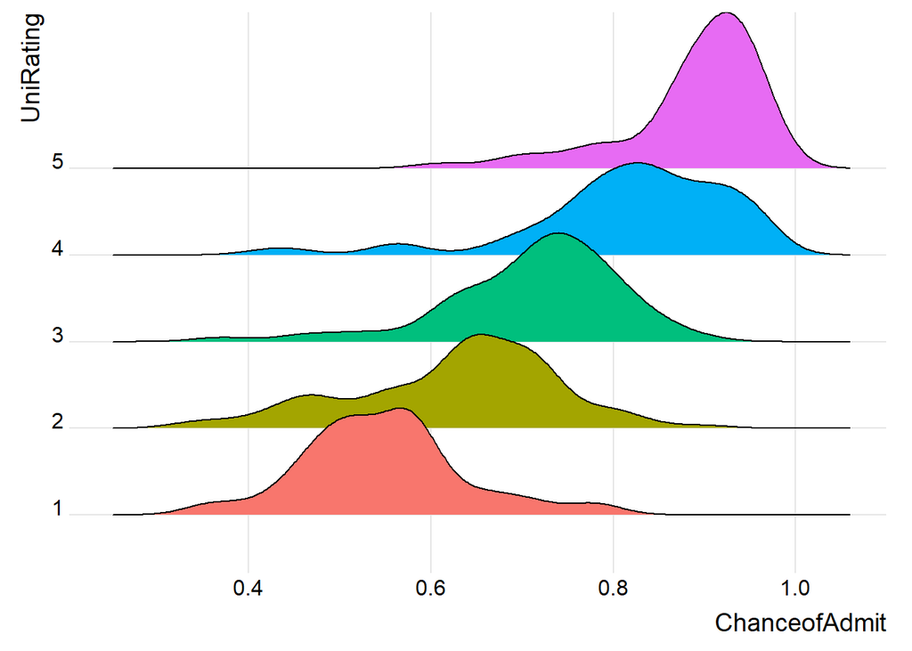

```r
ggplot(Admission_Predict, aes(x = ChanceofAdmit, y = UniRating, fill = UniRating)) +
  geom_density_ridges() +
  theme_ridges() +
  theme(legend.position = "none")
```

Bu grafikte universite notu yukseldikce yuksek lisansa kabul sansinin arttigini gorebiliriz.

0.0298 ortak bant genisligi toplama ;Picking joint bandwidth of 0.0298

## IKILIGRAFIK

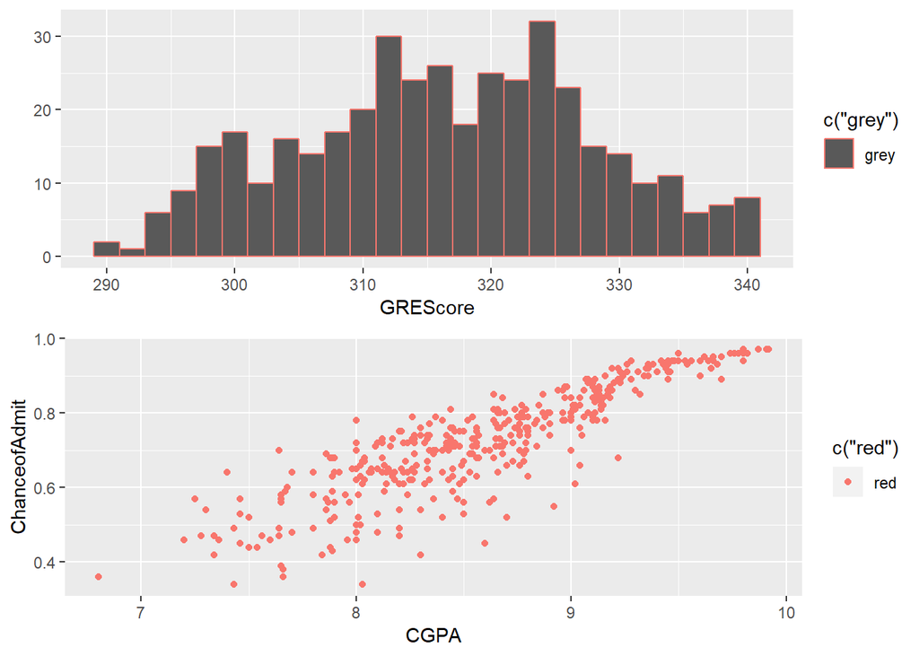

```r
library(gridExtra)
library(ggplot2)
#data(Admission_Predict)
plot1 <- qplot(GREScore,data=Admission_Predict,binwidth=2,colour=c("grey"))
plot2 <- qplot(CGPA,ChanceofAdmit,data=Admission_Predict,colour =c("red"))
grid.arrange(plot1,plot2,ncol=1)
```

birinci grafik bize mezuniyet notlarinin histogramini veriyor. ikinci grafikte kabul sansinin donem sonu notuyla dogrusal ilskisi oldugunu gorebiliriz. yani donem sonu notu arttikca kabul edilme sansi da artar denebilir.

# ÇOKLU GRAFIK

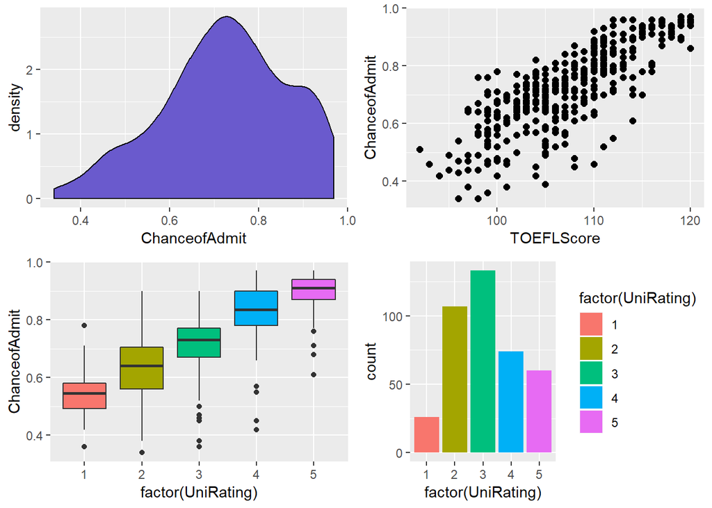

```r
library(ggplot2)
library(gridExtra)

g1=ggplot(Admission_Predict, aes(x=ChanceofAdmit)) + geom_density(fill="slateblue")
g2=ggplot(Admission_Predict, aes(x=TOEFLScore, y=ChanceofAdmit)) + geom_point(size=2) + theme(legend.position="none")
g3=ggplot(Admission_Predict, aes(x=factor(UniRating), y=ChanceofAdmit, fill=UniRating)) + geom_boxplot() + theme(legend.position="none")
g4=ggplot(Admission_Predict , aes(x=factor(UniRating), fill=factor(UniRating))) +  geom_bar()

grid.arrange(g1, g2, g3, g4, ncol=2, nrow =2)
```

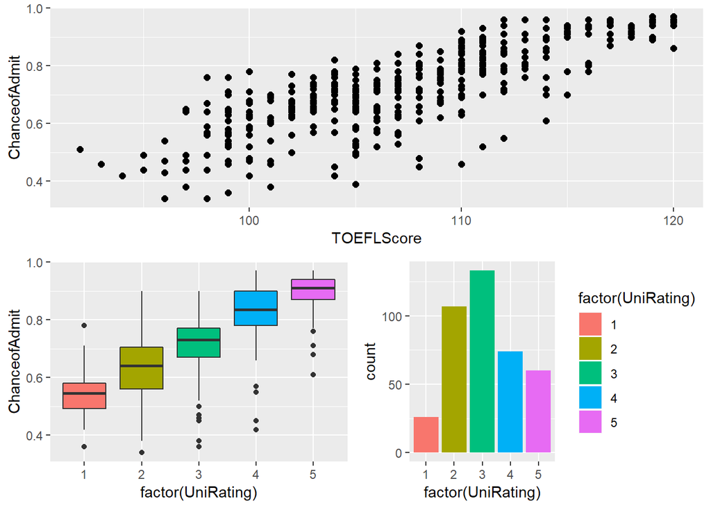

```r
grid.arrange(g2, arrangeGrob(g3, g4, ncol=2), nrow = 2)
```

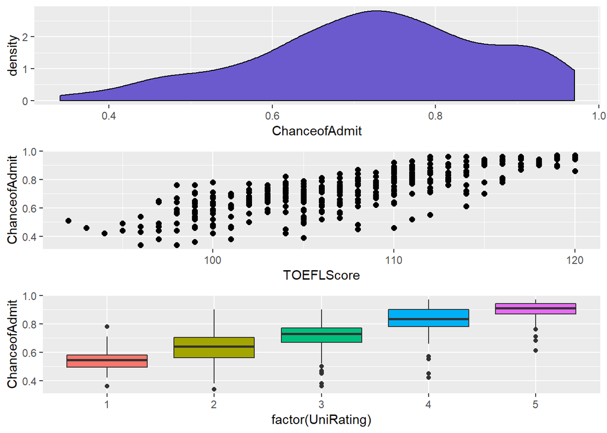

```r
grid.arrange(g1, g2, g3, nrow = 3)
```

[figure not shown]

```r
grid.arrange(g2, arrangeGrob(g3, g4, ncol=2), nrow = 1)
```

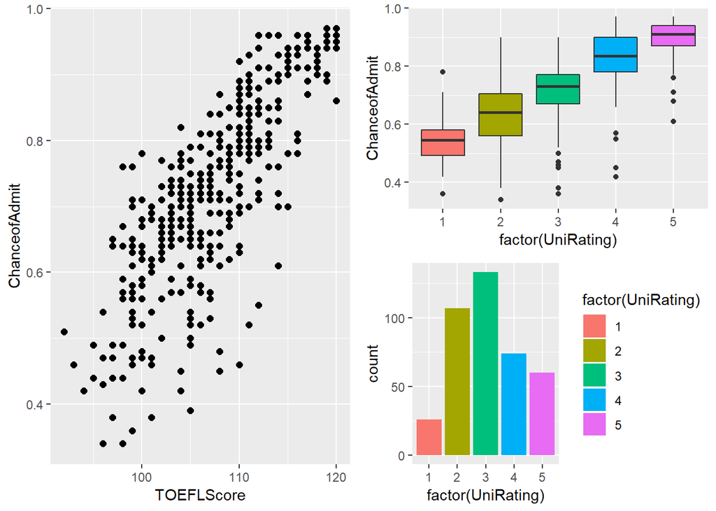

```r
grid.arrange(g2, arrangeGrob(g3, g4, nrow=2), nrow = 1)
```

*kabul sansinin 0.6 ve 0.8 arasinda genis bir dagiliminin oldugunu soyleyebiliriz.* toefl notu ve kabul sansinin dogrusal iliskili oldugunu soyleyebiliriz. yani toefl notu arttikca kabul sansi da artar. *bu boxplot bize universite notlarinin kabul sansina gore siralamasini gosterir. Burada universite notlari arttikca kabul sanssinin da arttigini soyleyebiliriz. Ancak aykiri degerler de vardir.* universite notlarinin kisi sayisi verilmistir. Ornegin; 3 notunu alan ~135 kisi vardir. 1 notunu alan ~25 kisi vardir.

```r
#library(corrplot)
#k=corrplot(cor(Admission_Predict), method="number")
```

### 2. MODELIN KURULMASI

## i. Dogrusal regresyon modelini kurunuz(kategorik degiskenlerin modele kategorik olarak girdigine emin olunuz). Sonuclarin ozetini ve ilgili anova tablosunu elde ediniz (glm(),summary(), anova()).

# ii. Aciklayici degiskenler ile bagimli degisken arasinda iliski var midir? Onemli buldugunuz model ciktilarini kullanarak detayli olarak aciklayiniz. 1 tane kategorik, 1 tane sayisal aciklayici degiskeni yorumlayiniz.

```r
rm1=lm(ChanceofAdmit~.,data=Admission_Predict)
rm1
```

```
##
## Call:
## lm(formula = ChanceofAdmit ~ ., data = Admission_Predict)
##
## Coefficients:
##  (Intercept)  `Serial No.`      GREScore    TOEFLScore    UniRating2
##   -1.2796377     0.0001639     0.0017838     0.0038753    -0.0119019
##   UniRating3    UniRating4    UniRating5           SOP           LOR
##   -0.0048113    -0.0023462     0.0238534     0.0010777     0.0219892
##         CGPA     Research1
##    0.1044863     0.0243754
```

```r
summary(rm1)
```

```
##
## Call:
## lm(formula = ChanceofAdmit ~ ., data = Admission_Predict)
##
## Residuals:
##       Min        1Q    Median        3Q       Max
## -0.230218 -0.025102  0.005412  0.037782  0.142223
##
## Coefficients:
##                Estimate Std. Error t value Pr(>|t|)
## (Intercept)  -1.280e+00  1.221e-01 -10.483  < 2e-16 ***
## `Serial No.`  1.639e-04  2.772e-05   5.911 7.46e-09 ***
## GREScore      1.784e-03  5.742e-04   3.106  0.00203 **
## TOEFLScore    3.875e-03  1.057e-03   3.667  0.00028 ***
## UniRating2   -1.190e-02  1.418e-02  -0.839  0.40175
## UniRating3   -4.811e-03  1.549e-02  -0.311  0.75620
## UniRating4   -2.346e-03  1.889e-02  -0.124  0.90120
## UniRating5    2.385e-02  2.090e-02   1.141  0.25453
## SOP           1.078e-03  5.383e-03   0.200  0.84142
## LOR           2.199e-02  5.320e-03   4.133 4.39e-05 ***
## CGPA          1.045e-01  1.196e-02   8.734  < 2e-16 ***
## Research1     2.438e-02  7.644e-03   3.189  0.00155 **
## ---
## Signif. codes:  0 '***' 0.001 '**' 0.01 '*' 0.05 '.' 0.1 ' ' 1
##
## Residual standard error: 0.06113 on 388 degrees of freedom
## Multiple R-squared:  0.8213, Adjusted R-squared:  0.8162
## F-statistic: 162.1 on 11 and 388 DF,  p-value: < 2.2e-16
```

Research1 degeri ile bagimli degisken arasinda anlamli bir iliski vardir. CGPA degeri ile bagimli degisken arasinda anlamli bir iliski vardir. #CGPA DEGERI VE KABUL SANSI ARASINDAKI ILISKI

```r
rm2=lm(ChanceofAdmit~CGPA,data=Admission_Predict)
rm2
```

```
##
## Call:
## lm(formula = ChanceofAdmit ~ CGPA, data = Admission_Predict)
##
## Coefficients:
## (Intercept)         CGPA
##     -1.0715       0.2088
```

```r
summary(rm2)
```

```
##
## Call:
## lm(formula = ChanceofAdmit ~ CGPA, data = Admission_Predict)
##
## Residuals:
##       Min        1Q    Median        3Q       Max
## -0.274575 -0.030084  0.009443  0.041954  0.180734
##
## Coefficients:
##             Estimate Std. Error t value Pr(>|t|)
## (Intercept) -1.07151    0.05034  -21.29   <2e-16 ***
## CGPA         0.20885    0.00584   35.76   <2e-16 ***
## ---
## Signif. codes:  0 '***' 0.001 '**' 0.01 '*' 0.05 '.' 0.1 ' ' 1
##
## Residual standard error: 0.06957 on 398 degrees of freedom
## Multiple R-squared:  0.7626, Adjusted R-squared:  0.762
## F-statistic:  1279 on 1 and 398 DF,  p-value: < 2.2e-16
```

F istatistiginin `1279` 1’den cok buyuk olmasi ve ilgili p degerinin 0’a cok yakin olmasi aralarinda anlamli bir iliski oldugunu gosterir.

Research1 degeri ile bagimli degisken arasinda anlamli bir iliski vardir. CGPA degeri ile bagimli degisken arasinda anlamli bir iliski vardir.

# iii. Her bir sayisal aciklayici degiskenin bagimli degisken ile dogrusal iliskili olup olmadigina bakmak icin grafikler ciziniz(lab3 kodlarini kullanabilirsiniz). Her bir aciklayci degisken ile bagimli degisken arasindaki iliski dogrusal midir? Yonu nedir ve model ciktilari ile grafikler tutarli midir?

```r
attach(Admission_Predict)
```

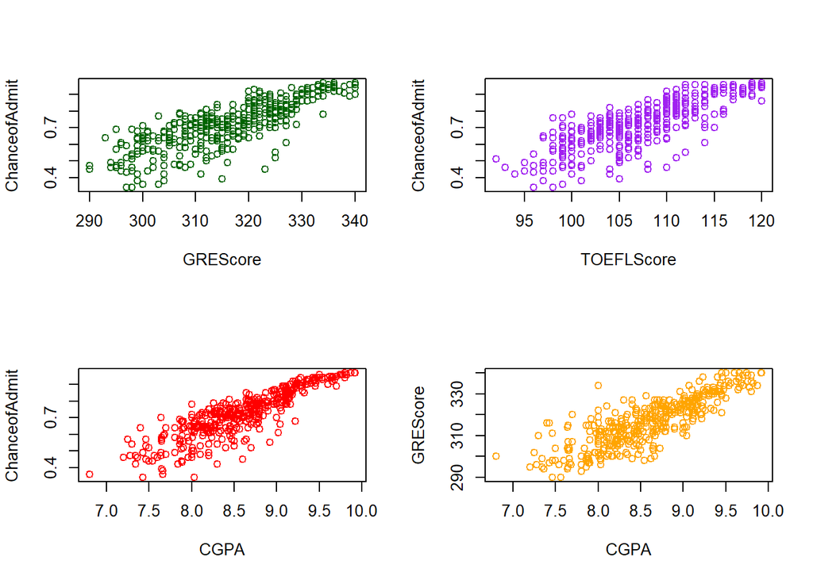

```r
par(mfrow=c(2,2))
plot(GREScore,ChanceofAdmit ,col=c("darkgreen"))
plot(TOEFLScore,ChanceofAdmit,col=c("purple"))
plot(CGPA,ChanceofAdmit,col=c("red"))
plot(CGPA,GREScore,col=c("orange"))
```

*mezuniyet notlari arttikca kabul sansi da artiyor.* toefl notlari arttikca kabul sansi da artiyor. *donem sonu agirlikli notlar arttikca kabul sansi da artiyor.* donem sonu agirlikli notlar arttikca mezuniyet notlari da artiyor. hepsinin arasinda dogrusal bir iliski oldugunu soyleyebiliriz.

# iv. Aciklayici degisken ile bagimli degisken arasindaki iliski ne kadar gucludur? Ilgili model ciktilarini kullanarak detayli olarak aciklayiniz.

Artiklarin standart hatasi(residual standard error(RSE)) bagimli degikenin gercek dogrusal modelden ortalama ne kadar saptigi ile ilgili bilgi verir. Dogrusal regresyon modelinde RSE `0.06957` bulunmustur. Bunun anlami her bir ogrenci icin kabul sansi degeri gercek dogrusal regresyon modelinden ortalama `0.06957` birim sapma gosterir.

RSE, modelin veriye uyumsuzlugunu gosteren bir degerdir. Kucuk olmasi tahmin edilen y(bagimli degisken)(ysapka) ve gozlenen y degerlerinin birbirine yakin oldugunu gosterir.

RSE, bagimli degiskenin birimine bagli oldugundan modelin iliski gucu yuzde hata (RSE/bagimli degiskenin ortalamasi) olarak verilir.

chanceofadmit’in ortalamasi `0.72435`’dir. bu durumda hata yuzdesi % `9.604473` olur.

Modelin $R^2$ degeri yaklasik `0.7626339`’dir. Bunun anlami chanceofadmit’in varyansinin % `76.2633851` kadari cgpa(donem sonu agirlikli notu) ile aciklanmaktadir.

# v. Sayisal degerler icin ortalama, kategorik degiskenler icin herhangi bir kategori alarak ilgili degerler icin %95 guven araligini(confidence interval) ve tahminin guven araligini (prediction interval) bulunuz. Yorumlayiniz

```r
 predict (rm2,data.frame(CGPA=c(8.598925)), interval="confidence") #ort cgpa degeri için kabul sansinin güven araligi
```

```
##       fit       lwr       upr
## 1 0.72435 0.7175118 0.7311882
```

```r
 predict (rm2,data.frame(CGPA=c(8.598925)), interval="prediction") #ort cgpa degeri için kabul sansinin tahmininin kestirim araligi
```

```
##       fit       lwr       upr
## 1 0.72435 0.5874148 0.8612852
```

### 3. VARSAYIMLARIN KONTROL EDILMESI

Modelin asagidaki varsayimlari saglayip saglamadigini inceleyiniz.(Grafiksel yontemlerle veya ilgili testlerle)

# i. Aciklayici degiskenler ve cikti degiskeni arasindaki iliskinin dogrusal olup olmadigi. Yorumlayiniz.

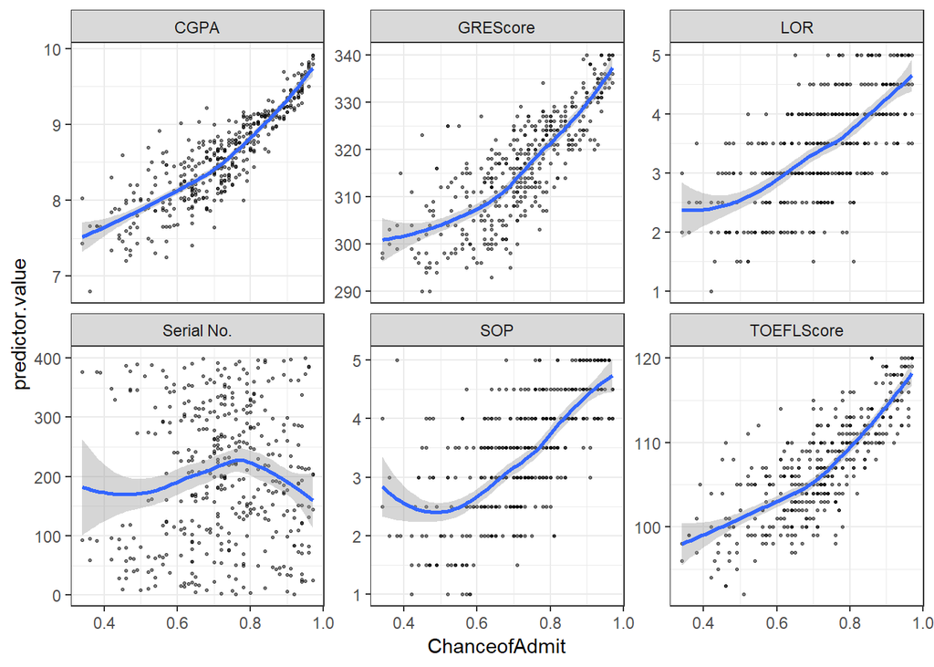

```r
library(dplyr)
library(tidyr)
mydata <- Admission_Predict%>%
  dplyr::select_if(is.numeric)
predictors <- colnames(mydata)[-1]
mydata <- mydata %>%
  mutate(ChanceofAdmit) %>%
  gather(key = "predictors", value = "predictor.value", -ChanceofAdmit)

library(ggplot2)
ggplot(mydata, aes(ChanceofAdmit, predictor.value))+
  geom_point(size = 0.5, alpha = 0.5) +
  geom_smooth(method = "loess") +
  theme_bw() +
  facet_wrap(~predictors, scales = "free_y")
```

CGPA, Toeflscore Grescore ve LOR degerleri bagimli degisken ile dogrusal iliski icerisindedir. SOP degeri ile dogrusal iliski vardir diyemeyiz.

## DIAGNOSTIK PLOTLAR

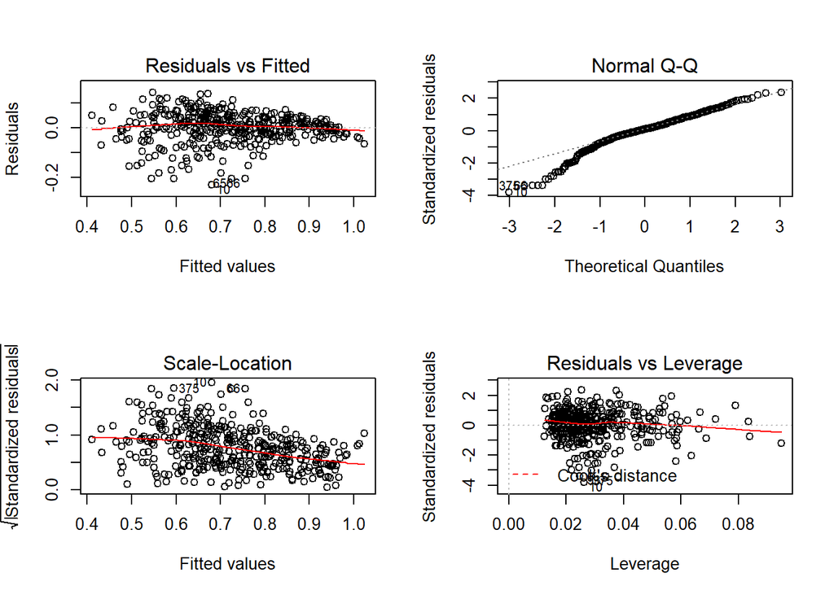

```r
par(mfrow=c(2,2))
plot(rm1)
```

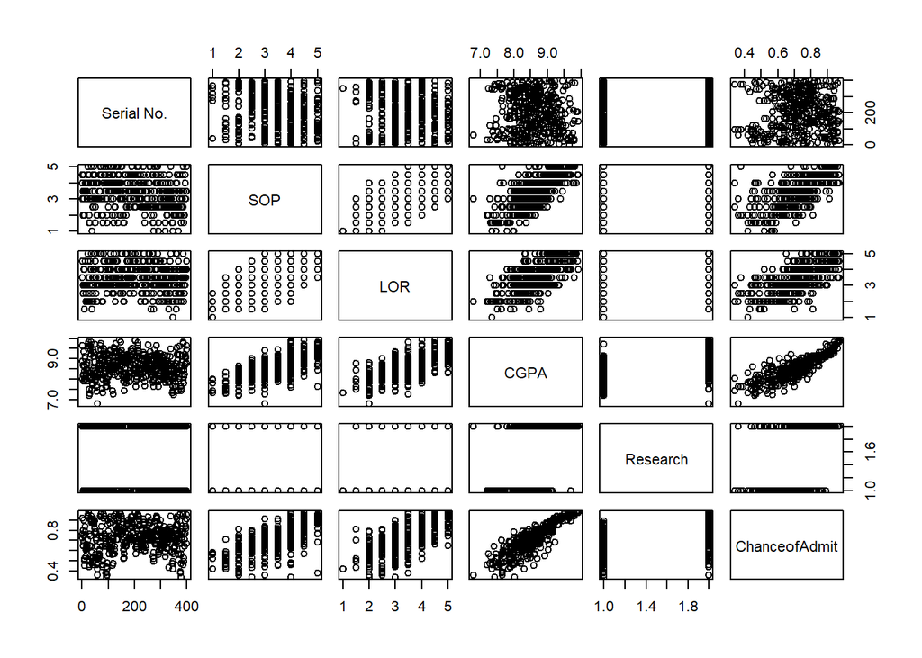

```r
  pairs(subset(Admission_Predict, select=c(-GREScore,-TOEFLScore,-UniRating)))
```

# ii. Hatalarin normal dagilip dagilmadigi. Yorumlayiniz.

Yatay cizgi etrafinda rasgele dagilmis artiklar gormek modelin uygun oldugunu gosterir.

# iii.Hatalarin birbirinden bagimsiz olmasi. Yorumlayiniz.

cizginin uc noktalarinda cok fazla rasgele olmayan degerler var ancak genel olarak dogrusal oldugundan normal dagildigini soyleyebiliriz. dolayisiyla hatalarin birbirinden bagimsiz oldugunu da soyleyebiliriz.

# iv. Hatalarin varyansinin sabit olmasi. Yorumlayiniz.

Homojen varyans durumunda yatay cizgi etrafinda rasgele olarak dagildiklari gozlenir. burada cizgi yatay degil ve degerler rasgele dagilmamis o yuzden varyanslar homojen degildir.

# v. Aykiri gozlemlerin kontrol edilmesi. Yorumlayiniz.

grafigin uc noktalarinda aykiri gozlemler vardir.

# vi.Yuksek kaldirac(high leverage) noktalarinin kontrol edilmesi. Yorumlayiniz.